# Medicare Provider Charge Data: Inpatient

Last update by Benjamin Chan (benjamin.ks.chan@gmail.com) on 2013-06-06 10:50:15 using R version 3.0.0 (2013-04-03).

Analyze CMS Medicare Provider Charge Data: Inpatient public use dataset. The data is documented and can be downloaded at the Medicare Provider Charge Data: Inpatient [website](http://www.cms.gov/Research-Statistics-Data-and-Systems/Statistics-Trends-and-Reports/Medicare-Provider-Charge-Data/Inpatient.html).

> The data provided here include hospital-specific charges for the more than 3,000 U.S. hospitals that receive Medicare Inpatient Prospective Payment System (IPPS) payments for the top 100 most frequently billed discharges, paid under Medicare based on a rate per discharge using the Medicare Severity Diagnosis Related Group (MS-DRG) for Fiscal Year (FY) 2011. These DRGs represent almost 7 million discharges or 60 percent of total Medicare IPPS discharges.

> Hospitals determine what they will charge for items and services provided to patients and these charges are the amount the hospital bills for an item or service. The Total Payment amount includes the MS-DRG amount, bill total per diem, beneficiary primary payer claim payment amount, beneficiary Part A coinsurance amount, beneficiary deductible amount, beneficiary blood deducible amount and DRG outlier amount.

> For these DRGs, average charges and average Medicare payments are calculated at the individual hospital level. Users will be able to make comparisons between the amount charged by individual hospitals within local markets, and nationwide, for services that might be furnished in connection with a particular inpatient stay.

## Reading and manipulating the data

Load the required libraries.

```r
require(RCurl, quietly = TRUE)
require(xtable, quietly = TRUE)
require(ggplot2, quietly = TRUE)
require(scales, quietly = TRUE)
require(RColorBrewer, quietly = TRUE)
```

RCurl with https is being tempermental. Copy the dataset to the local folder and `read.table` from there. Read the entire dataset.

```r
# url <-
# getURL('https://dl.dropboxusercontent.com/u/386956/Medicare_Provider_Charge_Inpatient_DRG100_FY2011.csv')
# df <- read.csv(textConnection(url), header=TRUE, sep=',')
df <- read.csv("Medicare_Provider_Charge_Inpatient_DRG100_FY2011.csv", header = TRUE,
    sep = ",")
```

The raw data has 163065 rows. Field names and the first few rows are below.

```r
names(df)
```

```
##  [1] "DRG.Definition"
##  [2] "Provider.Id"
##  [3] "Provider.Name"
##  [4] "Provider.Street.Address"
##  [5] "Provider.City"
##  [6] "Provider.State"
##  [7] "Provider.Zip.Code"
##  [8] "Hospital.Referral.Region.Description"
##  [9] "Total.Discharges"
## [10] "Average.Covered.Charges"
## [11] "Average.Total.Payments"
```

```r
head(df)
```

```
##                                                    DRG.Definition
## 1                        039 - EXTRACRANIAL PROCEDURES W/O CC/MCC
## 2             057 - DEGENERATIVE NERVOUS SYSTEM DISORDERS W/O MCC
## 3      064 - INTRACRANIAL HEMORRHAGE OR CEREBRAL INFARCTION W MCC
## 4       065 - INTRACRANIAL HEMORRHAGE OR CEREBRAL INFARCTION W CC
## 5 066 - INTRACRANIAL HEMORRHAGE OR CEREBRAL INFARCTION W/O CC/MCC
## 6                                        069 - TRANSIENT ISCHEMIA
##   Provider.Id                    Provider.Name Provider.Street.Address
## 1       10001 SOUTHEAST ALABAMA MEDICAL CENTER  1108 ROSS CLARK CIRCLE
## 2       10001 SOUTHEAST ALABAMA MEDICAL CENTER  1108 ROSS CLARK CIRCLE
## 3       10001 SOUTHEAST ALABAMA MEDICAL CENTER  1108 ROSS CLARK CIRCLE
## 4       10001 SOUTHEAST ALABAMA MEDICAL CENTER  1108 ROSS CLARK CIRCLE
## 5       10001 SOUTHEAST ALABAMA MEDICAL CENTER  1108 ROSS CLARK CIRCLE
## 6       10001 SOUTHEAST ALABAMA MEDICAL CENTER  1108 ROSS CLARK CIRCLE
##   Provider.City Provider.State Provider.Zip.Code
```

[output cut: 20 more lines]

Also read a MDC-DRG mapping table. This table comes from [CMS](http://www.cms.gov/Medicare/Medicare-Fee-for-Service-Payment/AcuteInpatientPPS/FY-2013-IPPS-Final-Rule-Home-Page-Items/FY2013-Final-Rule-Tables.html), [Table 5](http://www.cms.gov/Medicare/Medicare-Fee-for-Service-Payment/AcuteInpatientPPS/Downloads/FY_13_FR_Table_5.zip). Finally, create an MDC label table.

```r
drg <- read.table("CMS-1588-F TABLE 5.txt", skip=2, nrows=751, sep="\t", col.names=c("drg", "postacute", "specialpay", "mdc", "type", "drglab", "drgwgt", "meanLOSg", "meanLOGa"))
mdc <- matrix(
  ncol=2,
  byrow=TRUE,
  data=c(
"PRE", "Pre-MDC",
"01" , "Nervous System",
"02" , "Eye",
"03" , "Ear, Nose, Mouth And Throat",
"04" , "Respiratory System",
"05" , "Circulatory System",
"06" , "Digestive System",
"07" , "Hepatobiliary System And Pancreas",
"08" , "Musculoskeletal System And Connective Tissue",
"09" , "Skin, Subcutaneous Tissue And Breast",
"10" , "Endocrine, Nutritional And Metabolic System",
"11" , "Kidney And Urinary Tract",
"12" , "Male Reproductive System",
"13" , "Female Reproductive System",
"14" , "Pregnancy, Childbirth And Puerperium",
"15" , "Newborn And Other Neonates (Perinatal Period)",
"16" , "Blood and Blood Forming Organs and Immunological Disorders",
"17" , "Myeloproliferative DDs (Poorly Differentiated Neoplasms)",
"18" , "Infectious and Parasitic DDs",
"19" , "Mental Diseases and Disorders",
"20" , "Alcohol/Drug Use or Induced Mental Disorders",
"21" , "Injuries, Poison And Toxic Effect of Drugs",
"22" , "Burns",
"23" , "Factors Influencing Health Status",
"24" , "Multiple Significant Trauma",
"25" , "Human Immunodeficiency Virus Infection"
    ),
  )
mdc <- data.frame(mdc)
names(mdc) <- c("mdc", "mdclab")
drg <- merge(drg, mdc, by=c("mdc"))
```

Create some new fields.

- `DRGnum` is a numeric vector of the MS-DRG number without the description
- `DRGchar` is a character vector of the MS-DRG number without the description
- `isOregon` is a logical vector indicating if the row is from provider in Oregon
- `isPDXmetro` is a logical vector indicating if the row is from a provider in the Portland metro hospital referral region
- `isOHSU` is a logical vector indicating if the row is from an OHSU provider

```r
df$DRGnum <- as.numeric(substr(df$DRG.Definition, 1, 3))
df$DRGchar <- substr(df$DRG.Definition, 1, 3)
df$isOregon <- df$Provider.State == "OR"
df$isPDXmetro <- grepl("^OR - Portland", df$Hospital.Referral.Region.Description)
df$isOHSU <- grepl("^OHSU", df$Provider.Name)
```

Now that we have DRG in numeric form, merge the dataset to the MDC-DRG lookup.

```r
df <- merge(df, drg, by.x = c("DRGnum"), by.y = c("drg"))
```

Get vector of MS-DRGs and MDCs that OHSU has data for.

```r
drgOHSU <- as.vector(df$DRGnum[df$isOHSU])
mdcOHSU <- as.vector(unique(df$mdc[df$isOHSU]))
```

Create a subset of rows with just the DRGs in vector `drgOHSU` and non-missing DRG type.

```r
dfSubset <- subset(df, DRGnum %in% drgOHSU & !is.na(type))
```

The subset data has 125746 rows. Field names and the first few rows are below.

```r
names(dfSubset)
```

```
##  [1] "DRGnum"
##  [2] "DRG.Definition"
##  [3] "Provider.Id"
##  [4] "Provider.Name"
##  [5] "Provider.Street.Address"
##  [6] "Provider.City"
##  [7] "Provider.State"
##  [8] "Provider.Zip.Code"
##  [9] "Hospital.Referral.Region.Description"
## [10] "Total.Discharges"
## [11] "Average.Covered.Charges"
## [12] "Average.Total.Payments"
## [13] "DRGchar"
## [14] "isOregon"
## [15] "isPDXmetro"
## [16] "isOHSU"
## [17] "mdc"
## [18] "postacute"
## [19] "specialpay"
## [20] "type"
## [21] "drglab"
## [22] "drgwgt"
## [23] "meanLOSg"
## [24] "meanLOGa"
## [25] "mdclab"
```

```r
head(dfSubset)
```

```
##      DRGnum                                      DRG.Definition
## 1080     57 057 - DEGENERATIVE NERVOUS SYSTEM DISORDERS W/O MCC
## 1081     57 057 - DEGENERATIVE NERVOUS SYSTEM DISORDERS W/O MCC
## 1082     57 057 - DEGENERATIVE NERVOUS SYSTEM DISORDERS W/O MCC
## 1083     57 057 - DEGENERATIVE NERVOUS SYSTEM DISORDERS W/O MCC
## 1084     57 057 - DEGENERATIVE NERVOUS SYSTEM DISORDERS W/O MCC
## 1085     57 057 - DEGENERATIVE NERVOUS SYSTEM DISORDERS W/O MCC
##      Provider.Id                       Provider.Name
## 1080      210057      SHADY GROVE ADVENTIST HOSPITAL
## 1081      300001                    CONCORD HOSPITAL
## 1082      310019 ST JOSEPH'S REGIONAL MEDICAL CENTER
## 1083      310017                    CHILTON HOSPITAL
## 1084      490011 BON SECOURS - DEPAUL MEDICAL CENTER
## 1085      450289     HARRIS COUNTY HOSPITAL DISTRICT
##      Provider.Street.Address  Provider.City Provider.State
```

[output cut: 41 more lines]

## Plot the data

Create function for plotting average covered charges.

```r
DistnPlot <- function(d, t) {
  ggplot(d, aes(x=DRGchar, y=Average.Covered.Charges)) +
#     geom_boxplot(alpha=1/2, fill="grey", outlier.size=0) +
    geom_violin(alpha=1/2, fill="grey") +
    geom_jitter(data=d[d$isPDXmetro & !d$isOHSU,], alpha=1/2, na.rm=TRUE) +
    geom_point(data=d[d$isOHSU,], alpha=2/3, color=rgb(0, 73, 144, max=255), size=5) +
    facet_wrap(~ type, ncol=1, scales="free") +
    scale_y_log10(breaks=c(1E4, 2E4, 4E4, 8E4, 16E4, 32E4), labels=c("$10", "$20", "$40", "$80", "$160", "$320")) +
    labs(title=t, x="DRG", y="Average Covered Charges ($1,000s)") +
    theme_bw() +
    theme(legend.position="bottom", panel.grid.major.x=element_blank(), panel.grid.major.y=element_line(color="grey"))
}
```

Plot each MDC. Facet by DRG type.

- Blue dot is OHSU
- Grey dots are Portland metro hospitals
- Violins represent the nationwide distribution

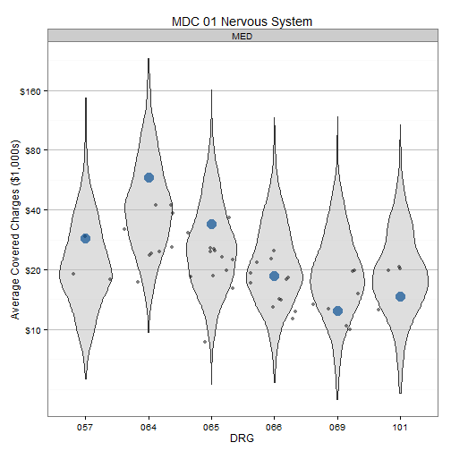

| drg | drglab |
| --- | --- |
| 57 | DEGENERATIVE NERVOUS SYSTEM DISORDERS W/O MCC |
| 64 | INTRACRANIAL HEMORRHAGE OR CEREBRAL INFARCTION W MCC |
| 65 | INTRACRANIAL HEMORRHAGE OR CEREBRAL INFARCTION W CC |
| 66 | INTRACRANIAL HEMORRHAGE OR CEREBRAL INFARCTION W/O CC/MCC |
| 69 | TRANSIENT ISCHEMIA |
| 101 | SEIZURES W/O MCC |

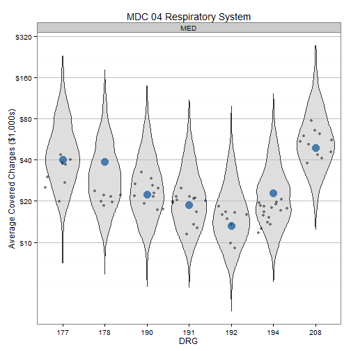

| drg | drglab |
| --- | --- |
| 177 | RESPIRATORY INFECTIONS &amp INFLAMMATIONS W MCC |
| 178 | RESPIRATORY INFECTIONS &amp INFLAMMATIONS W CC |
| 190 | CHRONIC OBSTRUCTIVE PULMONARY DISEASE W MCC |
| 191 | CHRONIC OBSTRUCTIVE PULMONARY DISEASE W CC |
| 192 | CHRONIC OBSTRUCTIVE PULMONARY DISEASE W/O CC/MCC |
| 194 | SIMPLE PNEUMONIA &amp PLEURISY W CC |
| 208 | RESPIRATORY SYSTEM DIAGNOSIS W VENTILATOR SUPPORT &lt 96 HOURS |

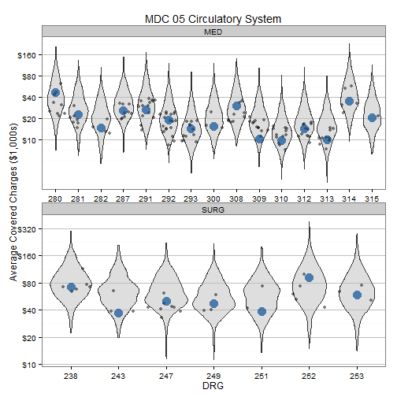

[output not shown]

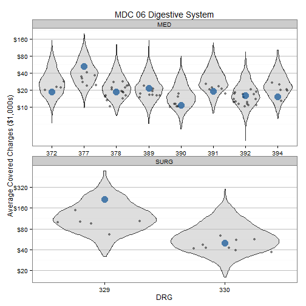

| drg | drglab |
| --- | --- |
| 329 | MAJOR SMALL &amp LARGE BOWEL PROCEDURES W MCC |
| 330 | MAJOR SMALL &amp LARGE BOWEL PROCEDURES W CC |
| 372 | MAJOR GASTROINTESTINAL DISORDERS &amp PERITONEAL INFECTIONS W CC |
| 377 | G.I. HEMORRHAGE W MCC |
| 378 | G.I. HEMORRHAGE W CC |
| 389 | G.I. OBSTRUCTION W CC |
| 390 | G.I. OBSTRUCTION W/O CC/MCC |
| 391 | ESOPHAGITIS, GASTROENT &amp MISC DIGEST DISORDERS W MCC |
| 392 | ESOPHAGITIS, GASTROENT &amp MISC DIGEST DISORDERS W/O MCC |
| 394 | OTHER DIGESTIVE SYSTEM DIAGNOSES W CC |

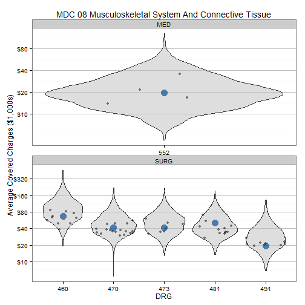

| drg | drglab |
| --- | --- |
| 460 | SPINAL FUSION EXCEPT CERVICAL W/O MCC |
| 470 | MAJOR JOINT REPLACEMENT OR REATTACHMENT OF LOWER EXTREMITY W/O MCC |
| 473 | CERVICAL SPINAL FUSION W/O CC/MCC |
| 481 | HIP &amp FEMUR PROCEDURES EXCEPT MAJOR JOINT W CC |
| 491 | BACK &amp NECK PROC EXC SPINAL FUSION W/O CC/MCC |
| 552 | MEDICAL BACK PROBLEMS W/O MCC |

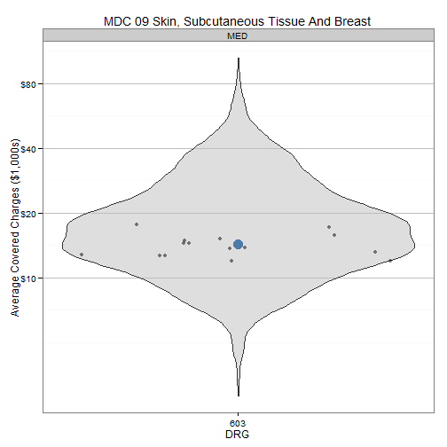

| drg | drglab |
| --- | --- |
| 603 | CELLULITIS W/O MCC |

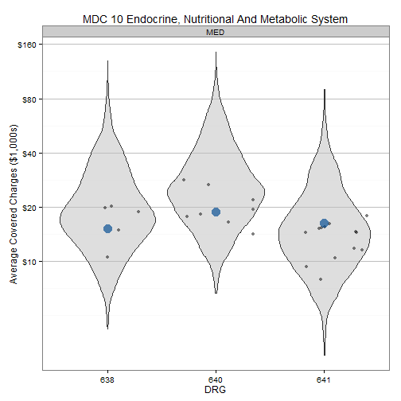

| drg | drglab |
| --- | --- |
| 638 | DIABETES W CC |
| 640 | MISC DISORDERS OF NUTRITION,METABOLISM,FLUIDS/ELECTROLYTES W MCC |
| 641 | MISC DISORDERS OF NUTRITION,METABOLISM,FLUIDS/ELECTROLYTES W/O MCC |

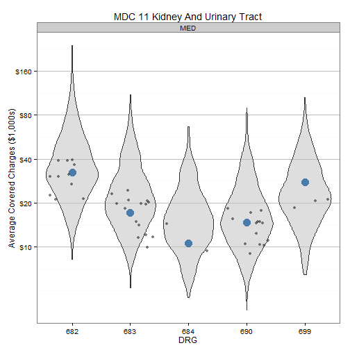

| drg | drglab |
| --- | --- |
| 682 | RENAL FAILURE W MCC |
| 683 | RENAL FAILURE W CC |
| 684 | RENAL FAILURE W/O CC/MCC |
| 690 | KIDNEY &amp URINARY TRACT INFECTIONS W/O MCC |
| 699 | OTHER KIDNEY &amp URINARY TRACT DIAGNOSES W CC |

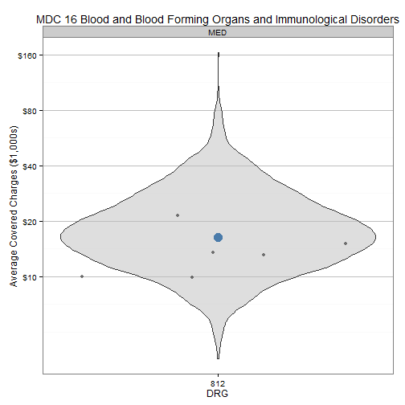

| drg | drglab |
| --- | --- |
| 812 | RED BLOOD CELL DISORDERS W/O MCC |

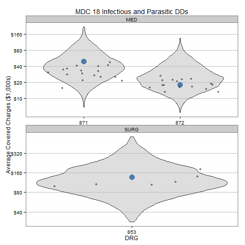

| drg | drglab |
| --- | --- |
| 853 | INFECTIOUS &amp PARASITIC DISEASES W O.R. PROCEDURE W MCC |
| 871 | SEPTICEMIA OR SEVERE SEPSIS W/O MV 96+ HOURS W MCC |
| 872 | SEPTICEMIA OR SEVERE SEPSIS W/O MV 96+ HOURS W/O MCC |

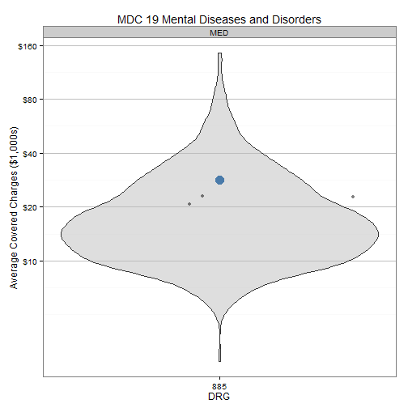

| drg | drglab |
| --- | --- |
| 885 | PSYCHOSES |

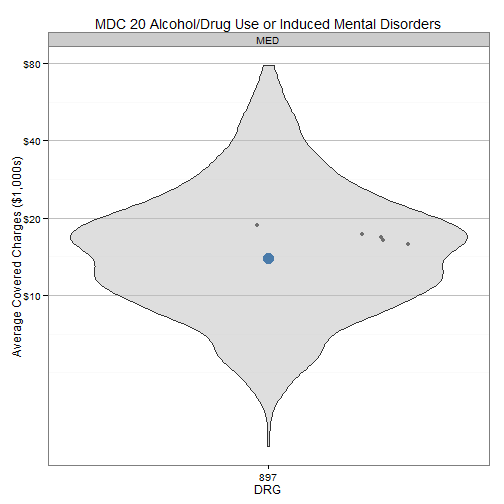

| drg | drglab |
| --- | --- |
| 897 | ALCOHOL/DRUG ABUSE OR DEPENDENCE W/O REHABILITATION THERAPY W/O MCC |

[2 more figures not shown]

| drg | drglab |
| --- | --- |
| 948 | SIGNS &amp SYMPTOMS W/O MCC |

```r
for (i in 1:length(mdcOHSU)) {
    j <- mdcOHSU[i]
    d <- subset(dfSubset, mdc == j)
    t <- paste("MDC", mdc$mdc[mdc == j], mdc$mdclab[mdc == j])
    show(DistnPlot(d, t))
    drglab <- subset(drg, drg %in% d$DRGnum, select = c(drg, drglab))
    drglab <- drglab[order(drglab$drg), ]
    print(xtable(drglab), type = "html", include.rownames = FALSE, comment = FALSE)
}
```